# FM-1.7.1净胜球形态与让平保护：固定方案探索

## 问题与预先固定的对照

目标不是让让平必然进入Top2，而是检验：让平单档排前二却在三分类排第三时，两侧累计是否主要由尾部堆积形成；集中/分散、集中位置不同，是否对应不同的保护价值。

基座为FM-1.7.1：同赛事原生lambda、冻结原生/市场来源决策、rho−0.1。四个固定方案为：完整选定来源分布SOURCE_FULL；正式FM171累计严格超过90%核心、外围0.3；核心80%外围0.3（CORE80_C03）；核心90%外围0.1（CORE90_C01）。前者减少核心档位，后者加重外围压缩。边界概率并列整组纳入，原独立retain审查保持原分布。所有方案都先重加权完整比分，再按北单线映射，不直接抬让平、不返拟合lambda、不强制排序。另展示冻结同赛事alpha及较晚北单对照。

所有参数在本轮评分前写入config/fm171_margin_shape_study.json，未用本轮目标标签择优；前述三期结果已知，本轮仍是事后探索，不能解释为盲测/滚动样本外。正式版本不变。没有新增采集、拟合、下注或线上发布。

## 输入、截止与合同

346个冻结fixture/cutoff，其中345场有标签。主分析排除23场同赛事原生支持不足而留存父版的行，共322场；混合345场仅作敏感性对照。229场市场路由仍按原冻结决策，原生成功替换94场；原生是否使用与是否已算出原生参数分别披露。

净胜球D=主进球−客进球；有符号北单让球h，让平档为−h；让胜=P(D>−h)、让平=P(D=−h)、让负=P(D<−h)。概率0–1，图示百分比。比分网格每行唯一主客进球组合；feature每fixture唯一；projection每fixture/model/outcome唯一且三类归一化；margin每fixture/model/integer margin唯一。critical输入哈希、截止或归一化失败立即停止。

逐场显式T−24h从父冻结包继承。Shared temporal_learning负责所有来源准入、最大时间、上下文/实现绑定、收据与重放，无客户端时序复制。新敏感性网格经build_adjustment_evidence_context、BuildFmTailJudgement、adjust_score_margin_distribution、project_score_outcomes形成；原生lambda只从封存same_support_raw重建。日粒度/盘口可用性含历史代理，不能授权前瞻使用。已有原生学习链prepare_opponent_goals、FitOpponentGoals及共享learning上下文不重新拟合；本次不选择参数、不训练分组阈值，来源切换也不重新裁决。输入源、模型、客户端及传递实现身份在manifest和逐场收据中绑定，换cutoff须重建，禁止缓存跨cutoff复用。

```r
suppressPackageStartupMessages(library(tidyverse))
root <- normalizePath(params$repository_root,mustWork=TRUE)
out <- file.path(root,params$output_dir)
manifest <- jsonlite::fromJSON(file.path(out,"manifest.json"))
replay <- jsonlite::fromJSON(file.path(out,"replay.json"))
stopifnot(replay$status=="FULL_IDENTICAL_REPLAY",replay$sha256==manifest$sha256,
 digest::digest(file=file.path(out,"forecasts.rds"),algo="sha256")==manifest$sha256)
status <- system2("/opt/R/4.6.1/bin/Rscript",shQuote(c(file.path(root,"r/fm171_margin_shape_evaluate.R"),root,out)),
 env=paste0("R_LIBS=",shQuote(paste(.libPaths(),collapse=":"))),stdout=file.path(out,"qmd-evaluation.log"),stderr=file.path(out,"qmd-evaluation.log"))
stopifnot(status==0L)
evaluation <- jsonlite::fromJSON(file.path(out,"evaluation.json"))
for(n in names(evaluation$output_hashes))stopifnot(digest::digest(file=file.path(out,paste0(n,".csv")),algo="sha256")==evaluation$output_hashes[[n]])
x <- readRDS(file.path(out,"forecasts.rds"))
metrics <- read_csv(file.path(out,"metrics.csv"),show_col_types=FALSE)
f <- read_csv(file.path(out,"features_labeled.csv"),show_col_types=FALSE)
cases <- read_csv(file.path(out,"cases.csv"),show_col_types=FALSE)
knitr::kable(x$features |> count(eligible,selected_source,native_changed),caption="估计覆盖；eligible排除父版留存原生")
```

估计覆盖；eligible排除父版留存原生

| eligible | selected_source | native_changed | n |
| --- | --- | --- | --- |
| FALSE | native | FALSE | 23 |
| TRUE | market | FALSE | 229 |
| TRUE | native | TRUE | 94 |

## 整体、逐期与误伤

Top1/Top2计数越高越好；Brier和log loss越低越好。saved/lost相对FM171逐场配对，净增等于救回减误伤；不能只展示救回。较晚北单不是同T−24h证据。

```r
knitr::kable(metrics |> filter(dimension=="all") |> select(cohort,model,n,hits1,hits2,brier,logloss,saved_top2,lost_top2),digits=6)
```

| cohort | model | n | hits1 | hits2 | brier | logloss | saved_top2 | lost_top2 |
| --- | --- | --- | --- | --- | --- | --- | --- | --- |
| ELIGIBLE_322 | ALPHA_SAME_COMPETITION | 322 | 100 | 226 | 0.672259 | 1.107775 | 52 | 57 |
| ELIGIBLE_322 | BEIDAN_LATER | 322 | 127 | 236 | 0.661327 | 1.090258 | 37 | 32 |
| ELIGIBLE_322 | CORE80_C03 | 322 | 133 | 234 | 0.664851 | 1.095369 | 9 | 6 |
| ELIGIBLE_322 | CORE90_C01 | 322 | 135 | 236 | 0.667127 | 1.099321 | 11 | 6 |
| ELIGIBLE_322 | FM171 | 322 | 134 | 231 | 0.666947 | 1.098898 | 0 | 0 |
| ELIGIBLE_322 | SOURCE_FULL | 322 | 130 | 225 | 0.667098 | 1.099202 | 16 | 22 |
| ALL_MIXED_345 | ALPHA_SAME_COMPETITION | 345 | 106 | 242 | 0.683902 | 1.124439 | 53 | 61 |
| ALL_MIXED_345 | BEIDAN_LATER | 345 | 130 | 244 | 0.670167 | 1.103727 | 38 | 44 |
| ALL_MIXED_345 | CORE80_C03 | 345 | 139 | 252 | 0.677779 | 1.111547 | 9 | 7 |
| ALL_MIXED_345 | CORE90_C01 | 345 | 141 | 253 | 0.679695 | 1.115175 | 11 | 8 |
| ALL_MIXED_345 | FM171 | 345 | 140 | 250 | 0.679412 | 1.114894 | 0 | 0 |
| ALL_MIXED_345 | SOURCE_FULL | 345 | 136 | 244 | 0.679238 | 1.115631 | 16 | 22 |

```r
knitr::kable(metrics |> filter(cohort=="ELIGIBLE_322",dimension=="issue_id") |>
 select(stratum,model,n,hits1,hits2,brier,logloss),digits=6,caption="主队列逐期表现")
```

主队列逐期表现

| stratum | model | n | hits1 | hits2 | brier | logloss |
| --- | --- | --- | --- | --- | --- | --- |
| 26098 | ALPHA_SAME_COMPETITION | 135 | 44 | 97 | 0.661530 | 1.092710 |
| 26101 | ALPHA_SAME_COMPETITION | 103 | 25 | 75 | 0.687886 | 1.123389 |
| 26102 | ALPHA_SAME_COMPETITION | 84 | 31 | 54 | 0.670340 | 1.112840 |
| 26098 | BEIDAN_LATER | 135 | 56 | 101 | 0.653333 | 1.078099 |
| 26101 | BEIDAN_LATER | 103 | 36 | 68 | 0.691688 | 1.133593 |
| 26102 | BEIDAN_LATER | 84 | 35 | 67 | 0.636947 | 1.056664 |
| 26098 | CORE80_C03 | 135 | 56 | 95 | 0.651201 | 1.078587 |
| 26101 | CORE80_C03 | 103 | 44 | 72 | 0.688218 | 1.125748 |
| 26102 | CORE80_C03 | 84 | 33 | 67 | 0.658137 | 1.085089 |
| 26098 | CORE90_C01 | 135 | 58 | 95 | 0.650640 | 1.077287 |
| 26101 | CORE90_C01 | 103 | 45 | 73 | 0.691066 | 1.131820 |
| 26102 | CORE90_C01 | 84 | 32 | 68 | 0.664271 | 1.094883 |
| 26098 | FM171 | 135 | 57 | 96 | 0.651276 | 1.078371 |
| 26101 | FM171 | 103 | 44 | 72 | 0.691028 | 1.131671 |
| 26102 | FM171 | 84 | 33 | 63 | 0.662606 | 1.091703 |
| 26098 | SOURCE_FULL | 135 | 55 | 91 | 0.654059 | 1.083099 |
| 26101 | SOURCE_FULL | 103 | 43 | 71 | 0.691651 | 1.133227 |
| 26102 | SOURCE_FULL | 84 | 32 | 63 | 0.657944 | 1.083362 |

## 集中程度与集中位置分别看

覆盖80%概率的最短连续整数区间，以整数档位数计宽；不强制围绕众数对称。相同宽度先取覆盖质量较大者，再按距均值、左端顺序确定。宽≤3为NARROW，4–5为MEDIUM，≥6为BROAD。让平及左右各一球合计质量≥0.6为HIGH，0.4–0.6为MEDIUM，低于0.4为LOW。这些仅是预先固定的描述分组，不作为新生产路由。让平单档名次用高于其概率1e−12的档位数加一，边界并列同名次；三类别排序并列按W、D、L，与既有诊断一致。

```r
knitr::kable(f |> filter(eligible) |> count(shape,line_locality,draw_group),caption="主队列分布形态及让平位置支持数")
```

主队列分布形态及让平位置支持数

| shape | line_locality | draw_group | n |
| --- | --- | --- | --- |
| BROAD | MEDIUM | DRAW_BIN_TOP2_CATEGORY3 | 6 |
| MEDIUM | HIGH | DRAW_BIN_OUTSIDE_TOP2 | 1 |
| MEDIUM | HIGH | DRAW_BIN_TOP2_ALREADY_INCLUDED | 131 |
| MEDIUM | HIGH | DRAW_BIN_TOP2_CATEGORY3 | 136 |
| MEDIUM | LOW | DRAW_BIN_OUTSIDE_TOP2 | 1 |
| MEDIUM | MEDIUM | DRAW_BIN_OUTSIDE_TOP2 | 5 |
| MEDIUM | MEDIUM | DRAW_BIN_TOP2_ALREADY_INCLUDED | 1 |
| MEDIUM | MEDIUM | DRAW_BIN_TOP2_CATEGORY3 | 41 |

```r
knitr::kable(metrics |> filter(cohort=="ELIGIBLE_322",dimension=="shape") |>
 select(stratum,model,n,hits1,hits2,saved_top2,lost_top2,brier,logloss),digits=5)
```

| stratum | model | n | hits1 | hits2 | saved_top2 | lost_top2 | brier | logloss |
| --- | --- | --- | --- | --- | --- | --- | --- | --- |
| BROAD | ALPHA_SAME_COMPETITION | 6 | 1 | 3 | 1 | 3 | 0.71774 | 1.17973 |
| MEDIUM | ALPHA_SAME_COMPETITION | 316 | 99 | 223 | 51 | 54 | 0.67140 | 1.10641 |
| BROAD | BEIDAN_LATER | 6 | 3 | 5 | 0 | 0 | 0.62921 | 1.03027 |
| MEDIUM | BEIDAN_LATER | 316 | 124 | 231 | 37 | 32 | 0.66194 | 1.09140 |
| BROAD | CORE80_C03 | 6 | 2 | 5 | 0 | 0 | 0.68591 | 1.11444 |
| MEDIUM | CORE80_C03 | 316 | 131 | 229 | 9 | 6 | 0.66445 | 1.09501 |
| BROAD | CORE90_C01 | 6 | 3 | 5 | 0 | 0 | 0.68896 | 1.11992 |
| MEDIUM | CORE90_C01 | 316 | 132 | 231 | 11 | 6 | 0.66671 | 1.09893 |
| BROAD | FM171 | 6 | 2 | 5 | 0 | 0 | 0.68442 | 1.11236 |
| MEDIUM | FM171 | 316 | 132 | 226 | 0 | 0 | 0.66662 | 1.09864 |
| BROAD | SOURCE_FULL | 6 | 2 | 5 | 0 | 0 | 0.67047 | 1.09014 |
| MEDIUM | SOURCE_FULL | 316 | 128 | 220 | 16 | 22 | 0.66703 | 1.09937 |

```r
knitr::kable(metrics |> filter(cohort=="ELIGIBLE_322",dimension=="line_locality") |>
 select(stratum,model,n,hits1,hits2,saved_top2,lost_top2,brier,logloss),digits=5)
```

| stratum | model | n | hits1 | hits2 | saved_top2 | lost_top2 | brier | logloss |
| --- | --- | --- | --- | --- | --- | --- | --- | --- |
| HIGH | ALPHA_SAME_COMPETITION | 268 | 77 | 186 | 37 | 45 | 0.67877 | 1.11750 |
| LOW | ALPHA_SAME_COMPETITION | 1 | 1 | 1 | 0 | 0 | 0.05918 | 0.22092 |
| MEDIUM | ALPHA_SAME_COMPETITION | 53 | 22 | 39 | 15 | 12 | 0.65088 | 1.07535 |
| HIGH | BEIDAN_LATER | 268 | 100 | 195 | 32 | 31 | 0.66687 | 1.09795 |
| LOW | BEIDAN_LATER | 1 | 0 | 1 | 0 | 0 | 0.62708 | 1.02005 |
| MEDIUM | BEIDAN_LATER | 53 | 27 | 40 | 5 | 1 | 0.63397 | 1.05268 |
| HIGH | CORE80_C03 | 268 | 108 | 193 | 4 | 5 | 0.67118 | 1.10480 |
| LOW | CORE80_C03 | 1 | 1 | 1 | 0 | 0 | 0.04051 | 0.16834 |
| MEDIUM | CORE80_C03 | 53 | 24 | 40 | 5 | 1 | 0.64463 | 1.06519 |
| HIGH | CORE90_C01 | 268 | 108 | 194 | 6 | 6 | 0.67369 | 1.10845 |
| LOW | CORE90_C01 | 1 | 1 | 1 | 0 | 0 | 0.04879 | 0.19544 |
| MEDIUM | CORE90_C01 | 53 | 26 | 41 | 5 | 0 | 0.64563 | 1.07023 |
| HIGH | FM171 | 268 | 109 | 194 | 0 | 0 | 0.67313 | 1.10725 |
| LOW | FM171 | 1 | 1 | 1 | 0 | 0 | 0.05099 | 0.20129 |
| MEDIUM | FM171 | 53 | 24 | 36 | 0 | 0 | 0.64732 | 1.07362 |
| HIGH | SOURCE_FULL | 268 | 105 | 189 | 16 | 21 | 0.67205 | 1.10512 |
| LOW | SOURCE_FULL | 1 | 1 | 1 | 0 | 0 | 0.05918 | 0.22092 |
| MEDIUM | SOURCE_FULL | 53 | 24 | 35 | 0 | 1 | 0.65352 | 1.08585 |

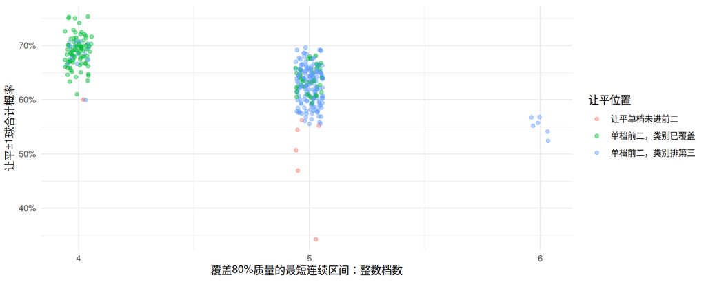

```r
f |> filter(eligible) |>
 ggplot(aes(interval80_positions,local_mass,colour=draw_group)) +
 geom_point(alpha=.45,position=position_jitter(width=.06,height=0,seed=171)) +
 scale_y_continuous(labels=scales::percent) + scale_x_continuous(breaks=c(4,5,6)) +
 scale_colour_discrete(labels=c(DRAW_BIN_OUTSIDE_TOP2="让平单档未进前二",DRAW_BIN_TOP2_ALREADY_INCLUDED="单档前二，类别已覆盖",DRAW_BIN_TOP2_CATEGORY3="单档前二，类别排第三")) +
 labs(x="覆盖80%质量的最短连续区间：整数档数",y="让平±1球合计概率",colour="让平位置") + theme_minimal()
```

## 核心问题：单档前二、类别第三

这里只能解释预先固定的敏感性方案是否改变了保护；样本少时不从一两场净增推导通用规则。两侧完整质量、核心/外围贡献CSV可逐场复核；相同精确胜差的不同比分条件比例保持不变。

```r
knitr::kable(metrics |> filter(cohort=="ELIGIBLE_322",dimension=="draw_group") |>
 select(stratum,model,n,hits1,hits2,saved_top2,lost_top2,brier,logloss),digits=5)
```

| stratum | model | n | hits1 | hits2 | saved_top2 | lost_top2 | brier | logloss |
| --- | --- | --- | --- | --- | --- | --- | --- | --- |
| DRAW_BIN_OUTSIDE_TOP2 | ALPHA_SAME_COMPETITION | 7 | 5 | 5 | 0 | 1 | 0.45060 | 0.80008 |
| DRAW_BIN_TOP2_ALREADY_INCLUDED | ALPHA_SAME_COMPETITION | 132 | 42 | 94 | 0 | 0 | 0.68333 | 1.12693 |
| DRAW_BIN_TOP2_CATEGORY3 | ALPHA_SAME_COMPETITION | 183 | 53 | 127 | 52 | 56 | 0.67275 | 1.10573 |
| DRAW_BIN_OUTSIDE_TOP2 | BEIDAN_LATER | 7 | 4 | 7 | 1 | 0 | 0.57507 | 0.96323 |
| DRAW_BIN_TOP2_ALREADY_INCLUDED | BEIDAN_LATER | 132 | 48 | 95 | 15 | 14 | 0.67778 | 1.11213 |
| DRAW_BIN_TOP2_CATEGORY3 | BEIDAN_LATER | 183 | 75 | 134 | 21 | 18 | 0.65276 | 1.07934 |
| DRAW_BIN_OUTSIDE_TOP2 | CORE80_C03 | 7 | 5 | 7 | 1 | 0 | 0.42168 | 0.72723 |
| DRAW_BIN_TOP2_ALREADY_INCLUDED | CORE80_C03 | 132 | 53 | 94 | 0 | 0 | 0.68412 | 1.12535 |
| DRAW_BIN_TOP2_CATEGORY3 | CORE80_C03 | 183 | 75 | 133 | 8 | 6 | 0.66025 | 1.08783 |
| DRAW_BIN_OUTSIDE_TOP2 | CORE90_C01 | 7 | 5 | 7 | 1 | 0 | 0.43833 | 0.76995 |
| DRAW_BIN_TOP2_ALREADY_INCLUDED | CORE90_C01 | 132 | 53 | 94 | 0 | 0 | 0.68379 | 1.12510 |
| DRAW_BIN_TOP2_CATEGORY3 | CORE90_C01 | 183 | 77 | 135 | 10 | 6 | 0.66386 | 1.09333 |
| DRAW_BIN_OUTSIDE_TOP2 | FM171 | 7 | 5 | 6 | 0 | 0 | 0.44109 | 0.77687 |
| DRAW_BIN_TOP2_ALREADY_INCLUDED | FM171 | 132 | 53 | 94 | 0 | 0 | 0.68402 | 1.12443 |
| DRAW_BIN_TOP2_CATEGORY3 | FM171 | 183 | 76 | 131 | 0 | 0 | 0.66328 | 1.09280 |
| DRAW_BIN_OUTSIDE_TOP2 | SOURCE_FULL | 7 | 5 | 5 | 0 | 1 | 0.45060 | 0.80008 |
| DRAW_BIN_TOP2_ALREADY_INCLUDED | SOURCE_FULL | 132 | 50 | 89 | 16 | 21 | 0.68543 | 1.12434 |
| DRAW_BIN_TOP2_CATEGORY3 | SOURCE_FULL | 183 | 75 | 131 | 0 | 0 | 0.66216 | 1.09251 |

```r
knitr::kable(cases |> filter(eligible,model %in% c("FM171","SOURCE_FULL","CORE80_C03","CORE90_C01")) |>
 select(fixture_id,home,away,handicap,model,actual_outcome,actual_rank,shape,interval80_positions,
 local_mass,draw_probability,raw_w,raw_l,top2,saved_top2,lost_top2),digits=4,caption="全部目标冲突场，含未改善/误伤")
```

全部目标冲突场，含未改善/误伤

| fixture_id | home | away | handicap | model | actual_outcome | actual_rank | shape | interval80_positions | local_mass | draw_probability | raw_w | raw_l | top2 | saved_top2 | lost_top2 |
| --- | --- | --- | --- | --- | --- | --- | --- | --- | --- | --- | --- | --- | --- | --- | --- |
| 26098:1 | 乌兹别克斯坦亚运男足 | 沙特阿拉伯亚运男足 | -1 | CORE80_C03 | W | 3 | MEDIUM | 4 | 0.7058 | 0.2546 | 0.3219 | 0.4236 | FALSE | FALSE | TRUE |
| 26098:1 | 乌兹别克斯坦亚运男足 | 沙特阿拉伯亚运男足 | -1 | CORE90_C01 | W | 2 | MEDIUM | 4 | 0.7058 | 0.2546 | 0.3219 | 0.4236 | TRUE | FALSE | FALSE |
| 26098:1 | 乌兹别克斯坦亚运男足 | 沙特阿拉伯亚运男足 | -1 | FM171 | W | 2 | MEDIUM | 4 | 0.7058 | 0.2546 | 0.3219 | 0.4236 | TRUE | FALSE | FALSE |
| 26098:1 | 乌兹别克斯坦亚运男足 | 沙特阿拉伯亚运男足 | -1 | SOURCE_FULL | W | 2 | MEDIUM | 4 | 0.7058 | 0.2546 | 0.3219 | 0.4236 | TRUE | FALSE | FALSE |
| 26098:100 | 夏洛特FC | 芝加哥火焰 | 0 | CORE80_C03 | L | 2 | MEDIUM | 5 | 0.5978 | 0.2424 | 0.4529 | 0.3047 | TRUE | FALSE | FALSE |
| 26098:100 | 夏洛特FC | 芝加哥火焰 | 0 | CORE90_C01 | L | 2 | MEDIUM | 5 | 0.5978 | 0.2424 | 0.4529 | 0.3047 | TRUE | FALSE | FALSE |
| 26098:100 | 夏洛特FC | 芝加哥火焰 | 0 | FM171 | L | 2 | MEDIUM | 5 | 0.5978 | 0.2424 | 0.4529 | 0.3047 | TRUE | FALSE | FALSE |
| 26098:100 | 夏洛特FC | 芝加哥火焰 | 0 | SOURCE_FULL | L | 2 | MEDIUM | 5 | 0.5978 | 0.2424 | 0.4529 | 0.3047 | TRUE | FALSE | FALSE |
| 26098:101 | CF蒙特利尔 | FC辛辛那提 | 0 | CORE80_C03 | W | 1 | MEDIUM | 5 | 0.6104 | 0.2492 | 0.3979 | 0.3529 | TRUE | FALSE | FALSE |
| 26098:101 | CF蒙特利尔 | FC辛辛那提 | 0 | CORE90_C01 | W | 1 | MEDIUM | 5 | 0.6104 | 0.2492 | 0.3979 | 0.3529 | TRUE | FALSE | FALSE |
| 26098:101 | CF蒙特利尔 | FC辛辛那提 | 0 | FM171 | W | 1 | MEDIUM | 5 | 0.6104 | 0.2492 | 0.3979 | 0.3529 | TRUE | FALSE | FALSE |
| 26098:101 | CF蒙特利尔 | FC辛辛那提 | 0 | SOURCE_FULL | W | 1 | MEDIUM | 5 | 0.6104 | 0.2492 | 0.3979 | 0.3529 | TRUE | FALSE | FALSE |
| 26098:103 | 费城联合 | 奥兰多城 | -1 | CORE80_C03 | W | 1 | BROAD | 6 | 0.5677 | 0.1988 | 0.4559 | 0.3453 | TRUE | FALSE | FALSE |
| 26098:103 | 费城联合 | 奥兰多城 | -1 | CORE90_C01 | W | 1 | BROAD | 6 | 0.5677 | 0.1988 | 0.4559 | 0.3453 | TRUE | FALSE | FALSE |
| 26098:103 | 费城联合 | 奥兰多城 | -1 | FM171 | W | 1 | BROAD | 6 | 0.5677 | 0.1988 | 0.4559 | 0.3453 | TRUE | FALSE | FALSE |
| 26098:103 | 费城联合 | 奥兰多城 | -1 | SOURCE_FULL | W | 1 | BROAD | 6 | 0.5677 | 0.1988 | 0.4559 | 0.3453 | TRUE | FALSE | FALSE |
| 26098:104 | 奥斯汀FC | 圣迭戈FC | 0 | CORE80_C03 | D | 3 | MEDIUM | 5 | 0.6267 | 0.2592 | 0.3900 | 0.3508 | FALSE | FALSE | FALSE |
| 26098:104 | 奥斯汀FC | 圣迭戈FC | 0 | CORE90_C01 | D | 3 | MEDIUM | 5 | 0.6267 | 0.2592 | 0.3900 | 0.3508 | FALSE | FALSE | FALSE |
| 26098:104 | 奥斯汀FC | 圣迭戈FC | 0 | FM171 | D | 3 | MEDIUM | 5 | 0.6267 | 0.2592 | 0.3900 | 0.3508 | FALSE | FALSE | FALSE |
| 26098:104 | 奥斯汀FC | 圣迭戈FC | 0 | SOURCE_FULL | D | 3 | MEDIUM | 5 | 0.6267 | 0.2592 | 0.3900 | 0.3508 | FALSE | FALSE | FALSE |
| 26098:105 | FC达拉斯 | 洛杉矶FC | 0 | CORE80_C03 | W | 1 | MEDIUM | 5 | 0.6258 | 0.2590 | 0.4186 | 0.3223 | TRUE | FALSE | FALSE |
| 26098:105 | FC达拉斯 | 洛杉矶FC | 0 | CORE90_C01 | W | 1 | MEDIUM | 5 | 0.6258 | 0.2590 | 0.4186 | 0.3223 | TRUE | FALSE | FALSE |
| 26098:105 | FC达拉斯 | 洛杉矶FC | 0 | FM171 | W | 1 | MEDIUM | 5 | 0.6258 | 0.2590 | 0.4186 | 0.3223 | TRUE | FALSE | FALSE |
| 26098:105 | FC达拉斯 | 洛杉矶FC | 0 | SOURCE_FULL | W | 1 | MEDIUM | 5 | 0.6258 | 0.2590 | 0.4186 | 0.3223 | TRUE | FALSE | FALSE |
| 26098:106 | 休斯顿迪纳摩 | 堪萨斯城体育 | -1 | CORE80_C03 | L | 1 | MEDIUM | 5 | 0.6383 | 0.2267 | 0.3976 | 0.3757 | TRUE | FALSE | FALSE |
| 26098:106 | 休斯顿迪纳摩 | 堪萨斯城体育 | -1 | CORE90_C01 | L | 2 | MEDIUM | 5 | 0.6383 | 0.2267 | 0.3976 | 0.3757 | TRUE | FALSE | FALSE |
| 26098:106 | 休斯顿迪纳摩 | 堪萨斯城体育 | -1 | FM171 | L | 2 | MEDIUM | 5 | 0.6383 | 0.2267 | 0.3976 | 0.3757 | TRUE | FALSE | FALSE |
| 26098:106 | 休斯顿迪纳摩 | 堪萨斯城体育 | -1 | SOURCE_FULL | L | 2 | MEDIUM | 5 | 0.6383 | 0.2267 | 0.3976 | 0.3757 | TRUE | FALSE | FALSE |
| 26098:107 | 纳什维尔SC | 多伦多FC | -1 | CORE80_C03 | W | 1 | MEDIUM | 5 | 0.6182 | 0.2191 | 0.4362 | 0.3446 | TRUE | FALSE | FALSE |
| 26098:107 | 纳什维尔SC | 多伦多FC | -1 | CORE90_C01 | W | 1 | MEDIUM | 5 | 0.6182 | 0.2191 | 0.4362 | 0.3446 | TRUE | FALSE | FALSE |

[output cut: 702 more lines]

## 让平保护与净胜球图核对

```r
scores <- read_csv(file.path(out,"scores.csv"),show_col_types=FALSE)
draw_ranks <- read_csv(file.path(out,"draw_ranks.csv"),show_col_types=FALSE)
knitr::kable(draw_ranks |> inner_join(f |> filter(eligible,target_conflict) |> select(fixture_id),
 by="fixture_id",relationship="many-to-one") |> group_by(model) |>
 summarise(n=n(),draw_in_top2=sum(draw_category_rank<=2),.groups="drop"),caption="目标冲突场中，让平真正进入Top2的场数")
```

目标冲突场中，让平真正进入Top2的场数

| model | n | draw_in_top2 |
| --- | --- | --- |
| CORE80_C03 | 183 | 27 |
| CORE90_C01 | 183 | 22 |
| FM171 | 183 | 0 |
| SOURCE_FULL | 183 | 0 |

```r
knitr::kable(scores |> filter(eligible,model %in% c("CORE80_C03","CORE90_C01"),saved_top2|lost_top2) |>
 count(model,actual_outcome,saved_top2,lost_top2),caption="救回与误伤的实际类别；不把全部改善归功于让平")
```

救回与误伤的实际类别；不把全部改善归功于让平

| model | actual_outcome | saved_top2 | lost_top2 | n |
| --- | --- | --- | --- | --- |
| CORE80_C03 | D | TRUE | FALSE | 9 |
| CORE80_C03 | L | FALSE | TRUE | 2 |
| CORE80_C03 | W | FALSE | TRUE | 4 |
| CORE90_C01 | D | TRUE | FALSE | 11 |
| CORE90_C01 | L | FALSE | TRUE | 1 |
| CORE90_C01 | W | FALSE | TRUE | 5 |

```r
knitr::kable(scores |> filter(eligible,model %in% c("FM171","CORE80_C03","CORE90_C01")) |>
 group_by(model,interval80_positions) |> summarise(n=n(),hits1=sum(top1),hits2=sum(top2),
 saved=sum(saved_top2),lost=sum(lost_top2),brier=mean(brier),.groups="drop"),digits=6,
 caption="按实际连续区间宽度描述，不另行选择阈值")
```

按实际连续区间宽度描述，不另行选择阈值

| model | interval80_positions | n | hits1 | hits2 | saved | lost | brier |
| --- | --- | --- | --- | --- | --- | --- | --- |
| CORE80_C03 | 4 | 105 | 43 | 73 | 4 | 5 | 0.686890 |
| CORE80_C03 | 5 | 211 | 88 | 156 | 5 | 1 | 0.653285 |
| CORE80_C03 | 6 | 6 | 2 | 5 | 0 | 0 | 0.685909 |
| CORE90_C01 | 4 | 105 | 43 | 75 | 3 | 2 | 0.685467 |
| CORE90_C01 | 5 | 211 | 89 | 156 | 8 | 4 | 0.657380 |
| CORE90_C01 | 6 | 6 | 3 | 5 | 0 | 0 | 0.688956 |
| FM171 | 4 | 105 | 43 | 74 | 0 | 0 | 0.685336 |
| FM171 | 5 | 211 | 89 | 152 | 0 | 0 | 0.657300 |
| FM171 | 6 | 6 | 2 | 5 | 0 | 0 | 0.684424 |

图例取目标冲突场按fixture_id字符顺序前3场，不按命中/失手挑例。只显示让平线左右各5球，纵轴保持原始质量，显示窗外尾部不归一化、不删除。

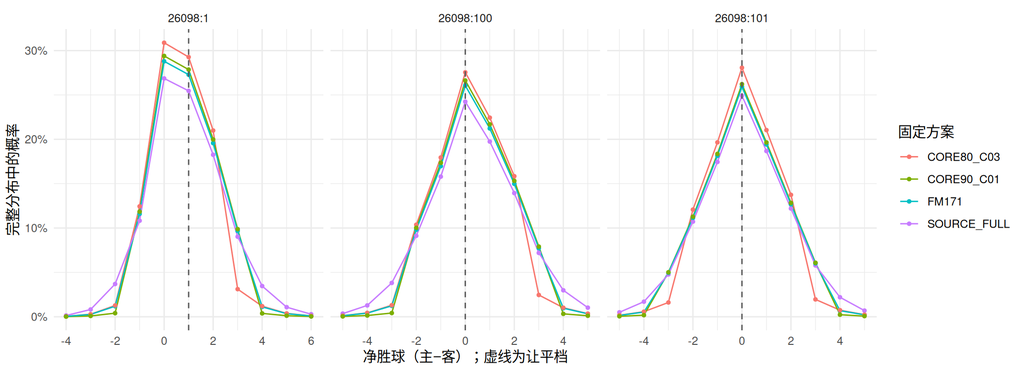

```r
examples <- f |> filter(eligible,target_conflict) |> arrange(fixture_id) |> slice_head(n=3)
mg <- read_csv(file.path(out,"margins.csv"),show_col_types=FALSE) |>
 inner_join(examples |> select(fixture_id,draw_margin),by="fixture_id",relationship="many-to-one") |>
 filter(abs(margin-draw_margin)<=5)
ggplot(mg,aes(margin,probability,colour=model)) + geom_line() + geom_point(size=1) +
 geom_vline(data=examples,aes(xintercept=draw_margin),inherit.aes=FALSE,linetype=2,colour="grey35") +
 facet_wrap(~fixture_id,scales="free_x") + scale_x_continuous(breaks=scales::breaks_width(2)) + scale_y_continuous(labels=scales::percent) +
 labs(x="净胜球（主−客）；虚线为让平档",y="完整分布中的概率",colour="固定方案") + theme_minimal()
```

## 排序差异究竟来自核心还是尾部

在FM171的90%核心中，把让平质量记作d，两侧核心质量记作A，让胜/让负各自外围质量记作T。此批目标组的让平档都位于核心，因此让平外围质量为零。统一外围系数c后，比较的是d与A+cT，共同归一化因子不影响排序。如果两侧核心各自已经超过d，即使把外围趋近于零，让平也不会进入Top2；这属于核心分布的含义，不能靠继续压尾解决。

下面只作现有固定方案的代数解释，不据结果拟合或选择新系数。对每一侧计算临界c=(d−A)/T，至少一侧达到时让平可能进Top2；与已封存0.1方案的实际排序逐场核验。这里没有执行c=0预测，也不删除比分尾部。

```r
contributions <- read_csv(file.path(out,"contributions.csv"),show_col_types=FALSE) |>
 group_by(fixture_id,outcome) |> summarise(core_mass=sum(mass[core]),tail_mass=sum(mass[!core]),.groups="drop") |>
 pivot_wider(names_from=outcome,values_from=c(core_mass,tail_mass),values_fill=0)
tail_audit <- f |> filter(eligible,target_conflict) |>
 left_join(contributions,by="fixture_id",relationship="one-to-one") |>
 mutate(core_blocks_draw=core_mass_D<=pmin(core_mass_W,core_mass_L)+1e-12,
  w_boundary=if_else(tail_mass_W>0,(core_mass_D-core_mass_W)/tail_mass_W,-Inf),
  l_boundary=if_else(tail_mass_L>0,(core_mass_D-core_mass_L)/tail_mass_L,-Inf),
  coefficient_boundary=pmax(w_boundary,l_boundary),
  predicted_draw_top2=review_decision=="apply" & coefficient_boundary>=.1-1e-12,
  tail_case=case_when(core_blocks_draw~"CORE_DOMINANT",
   coefficient_boundary>=.1~"C01_SUFFICIENT",TRUE~"NEEDS_C_BELOW_01")) |>
 left_join(draw_ranks |> filter(model=="CORE90_C01") |> select(fixture_id,c01_rank=draw_category_rank),
 by="fixture_id",relationship="one-to-one")
stopifnot(nrow(tail_audit)==183L,all(tail_audit$tail_mass_D==0),
 all(tail_audit$predicted_draw_top2==(tail_audit$c01_rank<=2L)))
knitr::kable(tail_audit |> group_by(tail_case) |> summarise(n=n(),actual_draws=sum(actual_outcome=="D"),
 actual_draw_rate=mean(actual_outcome=="D"),.groups="drop"),digits=4,caption="核心主导与尾部可改变的场景；临界系数不作拟合")
```

核心主导与尾部可改变的场景；临界系数不作拟合

| tail_case | n | actual_draws | actual_draw_rate |
| --- | --- | --- | --- |
| C01_SUFFICIENT | 22 | 10 | 0.4545 |
| CORE_DOMINANT | 147 | 40 | 0.2721 |
| NEEDS_C_BELOW_01 | 14 | 2 | 0.1429 |

183场中147场属于核心两侧质量本已压过让平，继续统一压尾不能改变这件事；其余36场才具有由外围压缩将让平推入Top2的空间。固定0.1能触及其中22场，实际让平10场；另外14场实际让平2场。这是已知结果的解释性分层，不能据此重新挑系数或称其为独立验证。

## 结论及局限

主队列322场中，FM171为134/231（Top1/Top2）；完整分布130/225；80%核心外围0.3为133/234，救回9场、误伤6场，Brier由0.666947降至0.664851；90%核心外围0.1为135/236，救回11场、误伤6场，但Brier升至0.667127。混合345场对应FM171 140/250、80%核心139/252、90%外围0.1为141/253。不同方案在选择覆盖与概率评分间存在取舍，尚不能确定单一优势规则。

让平单档前二但类别第三的183场中，80%核心让27场的让平进入Top2，90%外围0.1让22场进入；并非普遍抬平。整个主队列的救回均为让平：前者救回9场、误伤4场让胜和2场让负，后者救回11场、误伤5场让胜和1场让负。80%核心在连续宽度4的105场净少1场Top2，在宽度5的211场净多4场；较集中并不自动意味着更适合加强压尾，许多较集中的让平本已在保护内。

本轮不登记赢家、不更新FM版本。各方案全部报告，分组阈值不根据结果调优。分散分布中的单档前二不必然值得保护；整体集中也不等于质量集中在让平附近。应检查精确胜差概率与两侧累计质量是否真实失衡，再决定后续假设。若要形成实际决策规则，必须冻结候选后，用标签在截止前可用的新期历史通过共享学习上下文确定/验证阈值，再作未见期验证。此次三期只支持探索。

本批主要为单组DC/联合市场lambda产生的单峰或相邻峰分布，缺少明显集中（宽≤3）样本，明显分散样本也很少，不能代表一般双峰混合赛况。rho为专家固定值、原置信路由未重审、23场原生不足、历史可用时间代理、部分已知结果、细分小样本、同一三期多次讨论等，均限制因果与推广解释。没有票单与收益重放，不报告ROI。

## 可复现验收

环境沿用既有显式项目解释器：R4.6.1、项目.venv/bin/python，依赖版本和库路径记录于runtime.json/test-environment.json；不在函数或渲染时安装。核心复现命令：

```bash
/opt/R/4.6.1/bin/Rscript r/fm171_margin_shape_freeze.R ROOT OUTPUT
/opt/R/4.6.1/bin/Rscript r/fm171_margin_shape_freeze.R ROOT OUTPUT replay
/opt/R/4.6.1/bin/Rscript r/fm171_margin_shape_evaluate.R ROOT OUTPUT
/opt/R/4.6.1/bin/Rscript tests/testthat.R
QUARTO_R=/opt/R/4.6.1/bin/R quarto render quarto/fm171_margin_shape_20261017.qmd --no-cache
```

无新包实现或项目函数：R客户端仅顶层编排现有包函数与tidyverse描述统计。对应test-fm171-margin-shape.R执行比分到三类聚合、集中宽度最短性、档内比例、质量/排名、独立评分重放、哈希篡改拒绝、cutoff/网格变异拒绝、救回误伤与加权分组对账；原函数自身边界测试仍由完整包套件执行。固定形态分组使用显式政策和逐场cutoff，未拟合或选择阈值。正式源码/策略不变。本轮无包文件修改，不要求重新安装包；完整仓库入口使用正常安装包及其DLL，不手工dyn.load或load_all。

```r
if(isTRUE(params$acceptance_required)) {
 a <- jsonlite::fromJSON(file.path(out,"acceptance.json"))
 stopifnot(a$status=="ACCEPTED",a$blocking_findings==0L)
 for(i in seq_len(nrow(a$files)))stopifnot(digest::digest(file=file.path(root,a$files$path[i]),algo="sha256")==a$files$sha256[i])
 knitr::kable(as_tibble(a$checks),caption="最终源码身份、完整测试与审查证据")
} else cat("预览：完整验收尚未完成，不能据此宣称交付通过。")
```

最终源码身份、完整测试与审查证据

| command | result |
| --- | --- |
| /opt/R/4.6.1/bin/Rscript r/fm171_margin_shape_freeze.R ROOT OUTPUT; repeat with replay (R_LIBS from runtime.json) | Both exit0; 346 fixtures FULL_IDENTICAL_REPLAY, source hashes and explicit cutoffs bound; labels unopened |
| /opt/R/4.6.1/bin/Rscript r/fm171_margin_shape_evaluate.R ROOT OUTPUT | Exit0; 322 eligible and345 mixed settled rows, all preset policies; no model selection or version modification |
| testthat::test_file(“tests/testthat/test-fm171-margin-shape.R”, package=“beidan”, load_helpers=FALSE, stop_on_failure=TRUE) | {“tests”: 3, “passed”: 57717, “failed”: 0, “errors”: 0, “skipped”: 0}; exact execution: SHAPE_TARGETED=1 .venv/bin/python results/fm171-margin-shape-20261017/verification-runner.py; includes independe… |
| /opt/R/4.6.1/bin/Rscript tests/testthat.R; launched by .venv/bin/python results/fm171-margin-shape-20261017/verification-runner.py with explicit test-environment.json | {“package”: {“tests”: 948, “passed”: 9153, “failed”: 0, “errors”: 0, “warnings”: 0, “skipped”: 0}, “repository”: {“tests”: 788, “passed”: 141208, “failed”: 0, “errors”: 0, “warnings”: 0, “skipped”: 2}… |
| Skipped cases, missing evidence | test-fundamentals-pipeline.R lines6 and44: integration bundle must be materialized by test setup; no #408 integration bundle supplied. All new study tests executed |
| Package scope/runtime | No packages/beidan change in this delivery; no new installation or Python suite required. Full R entry uses normally installed r_lib/beidan and installed backend/DLL wrappers. No manual dyn.load/load_… |
| codex review ‘Final review only fixed FM171 margin shape study after QMD core/tail audit addition: config/fm171_margin_shape_study.json, r/fm171_margin_shape_freeze.R, r/fm171_margin_shape_evaluate.R,… | No actionable defects; final hashes in this table/receipt; final complete test outcomes verified separately |
| QUARTO_R=/opt/R/4.6.1/bin/R quarto render quarto/fm171_margin_shape_20261017.qmd –no-cache | Exit0; clean session/no cache, source hash gates pass; 13tables,2figures, no execution errors; final figures visually inspected, HTML hash in html-validation.json |
| Reviewed SHA256: config/fm171_margin_shape_study.json | 37b9d95e905db55b63e8a8d8f6425dd8f5c7923667abc7cdd93c48de46599bbd |
| Reviewed SHA256: r/fm171_margin_shape_freeze.R | af16c00f8d06fe33b808df81eaee245850232db0e7a7d08af8123acddfdd6471 |
| Reviewed SHA256: r/fm171_margin_shape_evaluate.R | 6c6a192cf7fdca2fad40dd6841ea98763eb3fea894649fdf29aa512ae7c5b487 |
| Reviewed SHA256: tests/testthat/test-fm171-margin-shape.R | d91bcbdc4327dbf3cf0f32bc634d3400bd567d58fc479f5bae971ca9076b7b83 |
| Reviewed SHA256: quarto/fm171_margin_shape_20261017.qmd | 93354471de8006bd2e50523663295d434ecbc924945c3e6e37d698d72f81c2e9 |
| Reviewed SHA256: results/fm171-margin-shape-20261017/verification-runner.py | 8d81cb6f03b930432e1ee016670033c4ce1180a422a472b0c391d2f6775c97a8 |